# Gene Expression Assessment

Michael Hunt

April 6, 2016

We have shown how Bioconductor provides resources for studying the human genome sequence as well as SNPs. Bioconductor also provides resources that permit us to obtain information about genes. We will see how these databases can be quite complex. But before learning about these here we present some experimental data.

The driving force behind the formation of the Bioconductor project was the emergence of high throughput measurement of gene expression data. Unlike genome sequence and SNP data, gene expression data varies from cell to cell, from tissue to tissue and from individual to individual. Statistical techniques such as those implemented in R were natural tools to parse out variability and perform statistical inference. Furthermore, the ambitious use of newly invented technologies added issues of measurement error and bias to an already difficulty challenge.

Note that in the previous assessments we focused on static database information: genome sequence and SNPs. In previous courses we have seen the `tissuesGeneExpression` data which is experimental data measured with microarrays. If you have not installed it you can do it like this:

```r
library(devtools)
install_github("genomicsclass/tissuesGeneExpression")
```

```
## Skipping install for github remote, the SHA1 (a43cf4b5) has not changed since last install.
##   Use `force = TRUE` to force installation
```

You can load the data:

```r
library(tissuesGeneExpression)
data(tissuesGeneExpression)
head(e[,1:5])
```

```
##           GSM11805.CEL.gz GSM11814.CEL.gz GSM11823.CEL.gz GSM11830.CEL.gz
## 1007_s_at       10.191267       10.509167       10.272027       10.252952
## 1053_at          6.040463        6.696075        6.144663        6.575153
## 117_at           7.447409        7.775354        7.696235        8.478135
## 121_at          12.025042       12.007817       11.633279       11.075286
## 1255_g_at        5.269269        5.180389        5.301714        5.372235
## 1294_at          8.535176        8.587241        8.277414        8.603650
##           GSM12067.CEL.gz
## 1007_s_at       10.157605
## 1053_at          6.606701
## 117_at           8.116336
## 121_at          10.832528
## 1255_g_at        5.334905
## 1294_at          8.303227
```

```r
table(tissue)
```

```
## tissue
##  cerebellum       colon endometrium hippocampus      kidney       liver
##          38          34          15          31          39          26
##    placenta
##           6
```

The rows of the matrix e are the features, in this case representing genes, and the columns are the samples. The entries of the matrix are gene expression measurements (in log scale) obtained using a microarray technology.

### Localization of expression to tissues

Look at the data for the feature with ID “209169_at”. You can index the rows of ‘e’ directly with this character string.

Which of the following best describes the data? (Hint: stratify data by tissue and create boxplots)

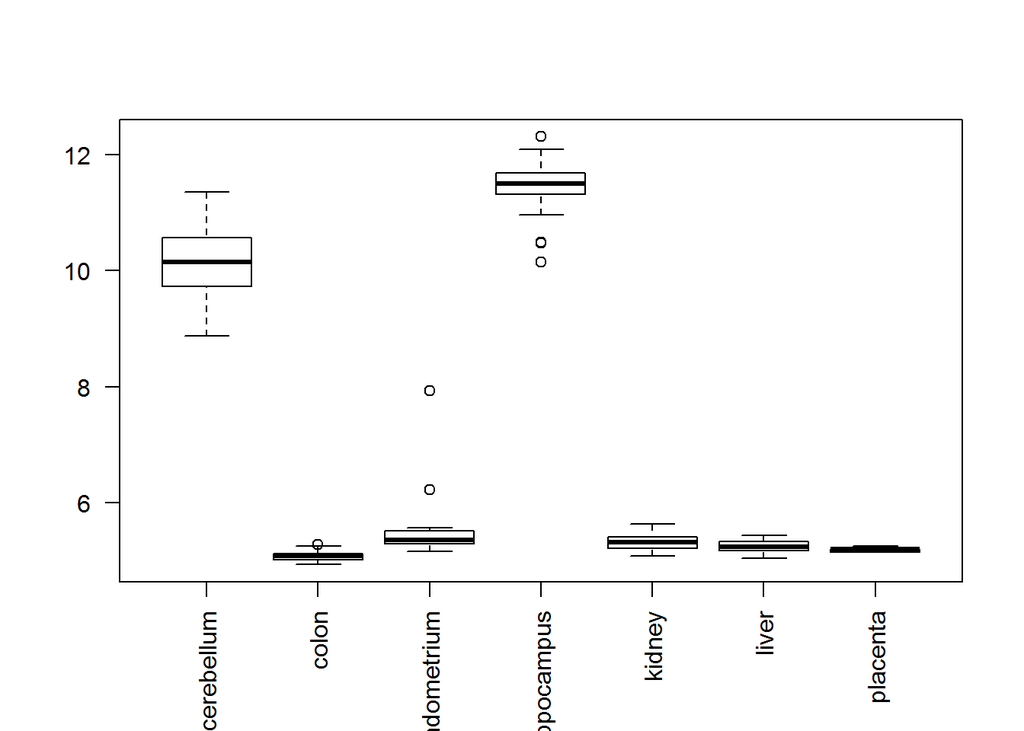

```r
boxplot(e["209169_at",]~tissue,las=2) # las=2 sets the axis label perpendicular
```

Answer:  
This gene is expressed in the brain but not the other tissues

### Comparing genes for tissue-specificity